# kepler

## Python and Kepler's Wine Barrel Problem

**Problem:** Find the dimensions of the barrel of largest volume that can be measured with rod of fixed length.

[figure not shown]

d - barrel width  
R - fixed rod length  
l - barrel length  
vol - barrel volume

If **Johannes Kepler** had some modern tool like **python** and its incarnation, **Jupyter Notebook**, he could easily have visualised the solution.

Barrel volume can be viewed as function of barrel width (diameter) and as function of barrel length. Barrel dimentions calculated with both methods should be the same.

## Barrel width (diameter) as argument

**Diameter range: d = 0 .. R**

[figure not shown]

From Pythagorean theorem:

$l = 2\sqrt{R^2 - d^2}$

Volume as a function of barrel width (diameter):

$vol(d) = \frac{\pi d^2}{4}l = \frac{\pi d^2}{2}\sqrt{R^2 - d^2}$

The first derivative of vol(d):

$vol^{'}(d) = \frac{\pi}{2}(2d\sqrt{R^2 - d^2} - \frac{d^3}{\sqrt{R^2 - d^2}})$

Find barrel dimentions of largest volume ($vol^{'}(d) = 0$)

$\sqrt{R^2 - d^2} = \frac{d^2}{2\sqrt{R^2 - d^2}}$

$R^2 - d^2 = \frac{d^2}{2}$

Barrel width (diameter) of largest volume:

$d_{max} = R\sqrt{\frac{2}{3}}$

Barrel length of largest volume:

$l_{max} = 2\sqrt{R^2 - \frac{2R^2}{3}} = \frac{2R}{\sqrt{3}}$

```python
import matplotlib.pyplot as plt
import numpy as np
%matplotlib inline
```

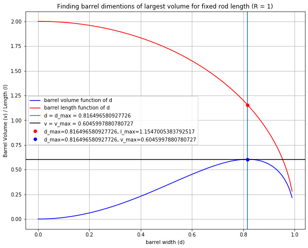

```python
# d - barrel width
# R - fixed rod length

R = 1

# barrel length function of d
length = lambda d:2*np.sqrt(R**2 - d**2)

# volume function of d
volume = lambda d:length(d)*(np.pi*d**2)/4

# barrel width (diameter) range with step = 0.01
d = np.arange(0,R,0.01)

# Barrel width (diameter) of largest volume:
d_max = R*np.sqrt(2/3)

# Barrel largest volume:
v_max = volume(d_max)

# Barrel length of largest volume:
l_max = length(d_max)

plt.figure(figsize = (10, 8))
plt.plot(d, volume(d), 'b', \
         label=f'barrel volume function of d')
plt.plot(d, length(d), 'r', \
         label=f'barrel length function of d')
plt.axvline(d_max, -10, 10, label=f'd = d_max = {d_max}')
plt.axhline(v_max, 0, 20, color = 'k', \
        label=f'v = v_max = {v_max}')
plt.plot([d_max],[l_max], 'ro', \
         label=f'd_max={d_max}, l_max={l_max}')
plt.plot([d_max],[v_max], 'bo', \
         label=f'd_max={d_max}, v_max={v_max}')
plt.xlabel('barrel width (d)')
plt.ylabel('Barrel Volume (v) / Length (l)')
plt.legend()
plt.title('Finding barrel dimentions of largest volume for fixed rod length (R = 1)')
plt.grid()
plt.show()
```

With python we can plot the curves for a range of rod lengths to see how quickly the barrel volume grows (cubic dependence of linear size)

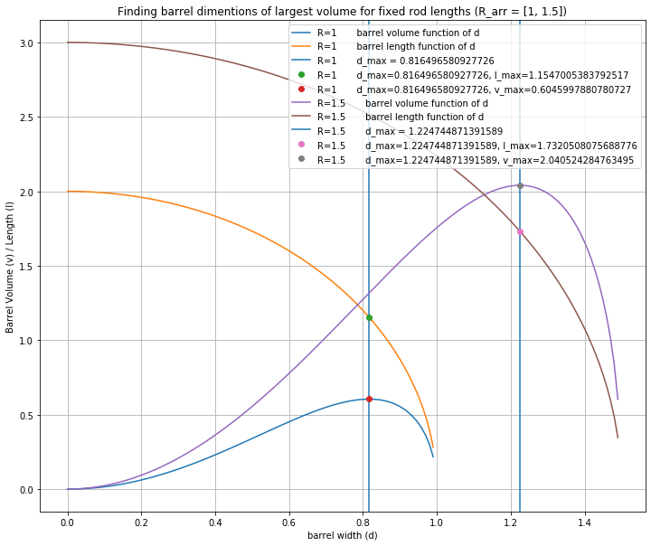

```python
# d - barrel width
# R - fixed rod length

# array of two rod lengths
R_arr = [1, 1.5]

# barrel length function (blen) of d
length = lambda d:2*np.sqrt(R**2 - d**2)
# volume function (vol) of d
volume = lambda d:length(d)*(np.pi*d**2)/4

plt.figure(figsize = (12, 10))

for R in R_arr:

    # barrel width (diameter) range with step = 0.01:
    d = np.arange(0,R,0.01)

    # barrel width of of largest volume:
    d_max = R*np.sqrt(2/3)

    # Barrel largest volume:
    v_max = volume(d_max)

    # Barrel length of largest volume:
    l_max = length(d_max)

    #plt.plot(d, volume(d), label=f'R={R}         volume')
    plt.plot(d, volume(d),\
        label=f'R={R}       barrel volume function of d')

    plt.plot(d, length(d), \
        label=f'R={R}       barrel length function of d')

    plt.axvline(d_max, -10, 10, \
        label=f'R={R}       d_max = {d_max}')

    plt.plot([d_max],[l_max], 'o', \
        label=f'R={R}       d_max={d_max}, l_max={l_max}')
    plt.plot([d_max],[v_max], 'o', \
        label=f'R={R}       d_max={d_max}, v_max={v_max}')

plt.xlabel('barrel width (d)')
plt.ylabel('Barrel Volume (v) / Length (l)')
plt.legend()
plt.title('Finding barrel dimentions of largest volume \
for fixed rod lengths (R_arr = [1, 1.5])')
plt.grid()
plt.show()
```

## Barrel length as argument

**Length range: L = 0 .. 2R**

[figure not shown]

$d^2 = R^2 - \frac{l^2}{4}$

$d = \sqrt{R^2 - \frac{l^2}{4}}$

Volume as a function of barrel length:

$vol(l) = \frac{\pi d^2}{4}l = \frac{\pi R^2 l}{4} - \frac{\pi l^3}{16}$

The first derivative of vol(l):

$vol^{'}(l) = \frac{\pi R^2}{4} - \frac{3 \pi l^2}{16}$

Find barrel dimentions of largest volume ($vol^{'}(l) = 0$)

$\frac{\pi R^2}{4} = \frac{3 \pi l^2}{16}$

Barrel length of largest volume:

$l = \frac{2R}{\sqrt{3}}$

Barrel width (diameter) of largest volume:

$d = \sqrt{R^2 - \frac{R^2}{3}} = R\sqrt{\frac{2}{3}}$

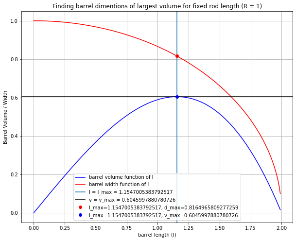

```python
# d - barrel width
# R - fixed rod length
# l - barrel length

R = 1

# barrel width function of l
width = lambda l:np.sqrt(R**2 - l**2 / 4)

# volume function of l
volume = lambda l:(l*np.pi*R**2)/4 - (l**3*np.pi)/16

# barrel length range with step = 0.01
l = np.arange(0,2*R,0.01)

# barrel length of largest volume:
l_max = 2*R/np.sqrt(3)

# Barrel largest volume:
v_max = volume(l_max)

# barrel width (diameter) of largest volume:
d_max = width(l_max)

plt.figure(figsize = (10, 8))
plt.plot(l, volume(l), 'b', \
    label=f'barrel volume function of l')
plt.plot(l, width(l), 'r', \
    label=f'barrel width function of l')
plt.axvline(l_max, -10, 10, \
    label=f'l = l_max = {l_max}')
plt.axhline(v_max, xmin=0, xmax=20, color = 'k', \
    label=f'v = v_max = {v_max}')
plt.plot([l_max],[d_max], 'ro', \
    label=f'l_max={l_max}, d_max={d_max}')
plt.plot([l_max],[v_max], 'bo', \
    label=f'l_max={l_max}, v_max={v_max}')
plt.xlabel('barrel length (l)')
plt.ylabel('Barrel Volume / Width')
plt.legend()
plt.title('Finding barrel dimentions of largest volume \
for fixed rod length (R = 1)')
plt.grid()
plt.show()
```

Plotting the curves for a range of rod lengths:

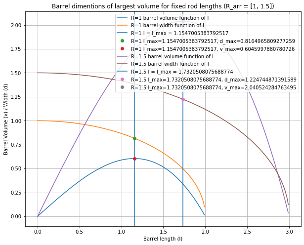

```python
# d - barrel width
# R - fixed rod length
# l - barrel length

# array of two rod lengths
R_arr = [1, 1.5]

# barrel width function of l
width = lambda l:np.sqrt(R**2 - l**2 / 4)

# volume function (vol) of l
volume = lambda l:(l*np.pi*R**2)/4 - (l**3*np.pi)/16

plt.figure(figsize = (10, 8))

for R in R_arr:

    # barrel length range with step = 0.01:
    l = np.arange(0,2*R,0.01)

    # barrel length of largest volume:
    l_max = 2*R/np.sqrt(3)

    # Barrel largest volume:
    v_max = volume(l_max)

    # barrel width (diameter) of largest volume:
    d_max = width(l_max)

    plt.plot(l, volume(l), \
        label=f'R={R} barrel volume function of l')
    plt.plot(l, width(l), \
        label=f'R={R} barrel width function of l')
    plt.axvline(l_max, -10, 10, \
        label=f'R={R} l = l_max = {l_max}')
    plt.plot([l_max],[d_max], 'o', \
        label=f'R={R} l_max={l_max}, d_max={d_max}')
    plt.plot([l_max],[v_max], 'o', \
        label=f'R={R} l_max={l_max}, v_max={v_max}')

plt.xlabel('Barrel length (l)')
plt.ylabel('Barrel Volume (v) / Width (d)')
plt.legend()
plt.title('Barrel dimentions of largest volume \
for fixed rod lengths (R_arr = [1, 1.5])')
plt.grid()
plt.show()
```

## Calibration Curve for barrels of optimal dimentions

Barrel volume as function of rod length

Barrel width (diameter) of largest volume:

$d_{max} = R\sqrt{\frac{2}{3}}$

Barrel length of largest volume:

$l_{max} = \frac{2R}{\sqrt{3}}$

Volume as a function of rod length:

$vol(d) = \frac{\pi d_{max}^2}{4}l_{max} = \frac{\pi R^3}{3\sqrt{3}}$

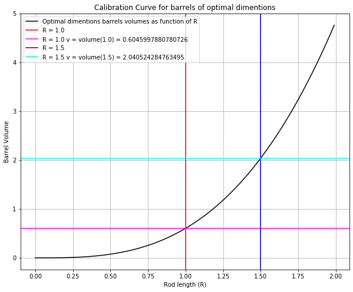

```python
# volume function of rod length (R)
volume = lambda R:(np.pi*R**3)/(3*np.sqrt(3))

# Rod range with step = 0.01
R = np.arange(0,2,0.01)

plt.figure(figsize = (10, 8))
plt.plot(R, volume(R), 'k', \
    label=f'Optimal dimentions barrels volumes as function of R')

# Find volume for R = 1 to see if the volume value matches the previous one
plt.axvline(1.0, -10, 10, color = 'r', label=f'R = 1.0')
plt.axhline(volume(1.0), xmin=0, xmax=20, color = 'magenta', \
    label=f'R = 1.0 v = volume(1.0) = {volume(1.0)}')

# Find also volume for R = 1.5
plt.axvline(1.5, -10, 10, color = 'b', label=f'R = 1.5')
plt.axhline(volume(1.5), xmin=0, xmax=20, color = 'cyan', \
    label=f'R = 1.5 v = volume(1.5) = {volume(1.5)}')

plt.xlabel('Rod length (R)')
plt.ylabel('Barrel Volume')
plt.legend()
plt.title('Calibration Curve for barrels of optimal dimentions')
plt.grid()
plt.show()
```